# Predicting Capital Bikeshare User-type, October 2024

[Anusha Umashankar](https://github.com/Anusha-raju)| [Aidan Carlisle](https://github.com/acarlisle8)| [Rachel Thomas](https://github.com/releered)| [Sayan Patra](https://github.com/Sayanpatraa) - Group 8

2024-12-13

# Introduction:

*Capital Bikeshare* is a bicycle-sharing system that serves Washington, D.C., and certain counties of the larger metropolitan area in both Maryland and Virginia. Users can select from electric or classic bikes at over 700 locations, either as a casual rider or with a monthly membership. The dataset is of October 2024.

# Literature Review

The earliest well-known community bicycle started in 1965 in Amsterdam, Netherlands. Since then cities of all sizes and around the world have introduced programs. Bike-sharing is a way to solve the “last mile” problem of public transit networks, providing a bridge between people’s homes and public transit hub (“Bicycle-sharing systems”, 2024). In 2008, Washington, DC became the first city in North America to launch a bike-sharing system, called SmartBike DC. Within a couple years, Arlington, VA, Alexandria, VA, and Montgomery County, MD collaborated with DC to form Capital Bikeshare in 2010 (Capital Bikeshare,2022).

Since it’s inception, extensive research has been done on bike-sharing, and on Capital Bikeshare specifically. In 2024, Sadeghvarziri et. al. analyzed the influential factors and dynamics of bikeshare utilization in DC. This study included more than 3 million ride obvervations, and concluded temporal trends highlighted peak mid-weekday ridership, aligning with daily work commutes, and that docked bikes are favored on weekdays, electric bikes on weekends, and members are less likely to choose classic bikes. (Sadeghvaziri et. al., 2024). This valuable information can be used to make data-driven decisions about the program.

Additionally, bikesharing in DC plays an integral role in transit accessibility in DC. In 2024, Tushar & Buehler (2024), found more bike trails, bike lanes, and metrorail stations within one mile of neighborhood docking stations and shorter distances between neighborhood docking stations are associated with more bikeshare trips. This reinforces the importance of infrastructure with respect to attracting bikeshare users (Tushar & Buehler 2024).

```r
file_path <- file.path(getwd(), "202410-capitalbikeshare-tripdata.csv")
capital_bikeshare <- read.csv(file_path, header = TRUE)
```

The dataset contains the following attributes.

```r
colnames(capital_bikeshare)
```

```
##  [1] "ride_id"            "rideable_type"      "started_at"
##  [4] "ended_at"           "start_station_name" "start_station_id"
##  [7] "end_station_name"   "end_station_id"     "start_lat"
## [10] "start_lng"          "end_lat"            "end_lng"
## [13] "member_casual"
```

# Preprocessing:

We began this project by evaluating the dataset for completeness and modified variables for usability.

Dropping the 478 rows as they constitute only 0.066 percent of the dataset.

```r
capital_bikeshare <- capital_bikeshare %>%
  filter(!is.na(end_lat))
```

2. `Distance (in miles)` is derived using the latitude and longitude coordinates of the start and end points. The `distVincentySphere()` function from the `geosphere` package in R is used to compute the geodesic distance, factoring in the Earth’s curvature.

```r
# Calculate the distance for each row and add it as a new column (in miles)
capital_bikeshare$distance_miles <- mapply(function(lat1, lon1, lat2, lon2) {
  distVincentySphere(c(lon1, lat1), c(lon2, lat2)) / 1000 * 0.621371
}, capital_bikeshare$start_lat, capital_bikeshare$start_lng, capital_bikeshare$end_lat, capital_bikeshare$end_lng)
```

3. Calculated the total ride time by subtracting `started_at` from `ended_at.`

```r
capital_bikeshare$started_at <- as.POSIXct(capital_bikeshare$started_at, format="%Y-%m-%d %H:%M:%OS")
capital_bikeshare$ended_at <- as.POSIXct(capital_bikeshare$ended_at, format="%Y-%m-%d %H:%M:%OS")
capital_bikeshare$ride_duration_mins <- as.numeric(difftime(capital_bikeshare$ended_at, capital_bikeshare$started_at, units = "mins"))
```

4. Categorizing Rides by Time Period.

```r
get_time_period <- function(time) {
  hour <- as.numeric(format(time, "%H"))

  if (hour >= 4 & hour < 6) {
    return("Early Morning")
  } else if (hour >= 6 & hour < 9) {
    return("Morning")
  } else if (hour >= 9 & hour < 12) {
    return("Mid-Morning")
  } else if (hour >= 12 & hour < 13) {
    return("Midday")
  } else if (hour >= 13 & hour < 17) {
    return("Afternoon")
  } else if (hour >= 17 & hour < 19) {
    return("Evening")
  } else if (hour >= 19 & hour < 21) {
    return("Late Evening")
  } else {
    return("Night")
  }
}


capital_bikeshare <- capital_bikeshare %>%
  mutate(
    start_time_period = sapply(started_at, get_time_period),
  )
```

5. Categorizing rides by weekday vs weekend

```r
capital_bikeshare$day_type <- ifelse(wday(capital_bikeshare$started_at) %in% c(1, 7), "weekend", "weekday")
```

**The following attributes are considered for further Exploratory Data Analysis (EDA):**

```r
filtered_capital_bikeshare <- capital_bikeshare %>% select(rideable_type,member_casual,distance_miles,ride_duration_mins, start_time_period,day_type)
```

*Factorizing ‘rideable_type’, ‘member_casual’, ‘start_time_period’, and ‘day_type’ variables:*

```r
filtered_capital_bikeshare$rideable_type <- as.factor(filtered_capital_bikeshare$rideable_type)
filtered_capital_bikeshare$member_casual <- as.factor(filtered_capital_bikeshare$member_casual)
filtered_capital_bikeshare$start_time_period <- as.factor(filtered_capital_bikeshare$start_time_period)
filtered_capital_bikeshare$day_type <- as.factor(filtered_capital_bikeshare$day_type)
```

*Removing outliers*

```r
#for distance_miles
z_scores_DM <- scale(filtered_capital_bikeshare$distance_miles)
outliers <- which(abs(z_scores_DM) > 3)
capital_bikeshare_clean <- filtered_capital_bikeshare[-outliers, ]

# for ride_duration_mins
z_scores_RDM <- scale(capital_bikeshare_clean$ride_duration_mins)
outliers <- which(abs(z_scores_RDM) > 2)
capital_bikeshare_clean <- capital_bikeshare_clean[-outliers, ]
```

After cleaning the dataset the number of rows are 703943.

The features considered for analysis are as follows:

`rideable_type`: This refers to the type of bike or vehicle used for the ride, such as electric bikes or classic bike.

`member_casual`: This variable categorizes users based on their membership status. “Member” refers to users who have a subscription or membership, while “Casual” refers to users who use the service on an ad-hoc, non-subscription basis.

`distance_miles`: This represents the distance traveled during the ride, measured in miles. It quantifies how far the rider has traveled using the bike-sharing service.

`ride_duration_mins`: This variable refers to the total time, in minutes, that the ride lasts. It measures how long the bike or vehicle is used during each ride.

`start_time_period`: This represents the time of day during which the ride starts, such as morning, afternoon, or evening. It helps to analyze patterns based on the time of use.

`day_type`: This variable refers to the type of day, such as weekdays (Monday to Friday) or weekends (Saturday-Sunday). This is useful for understanding usage patterns depending on the type of day.

# Exploratory Data Analysis

This project aims to predict user type (member versus casual) based on trip characteristics. Our exploratory data analysis focused first on understanding the fundamental shape of the dataset’s variables, and then on the relationship between the features and the predictor (member_casual). We used this information both to guide how we added features to the models, as well as to bolster the resultant findings from the models.

## Frequency of electric bike versus classic bike rentals

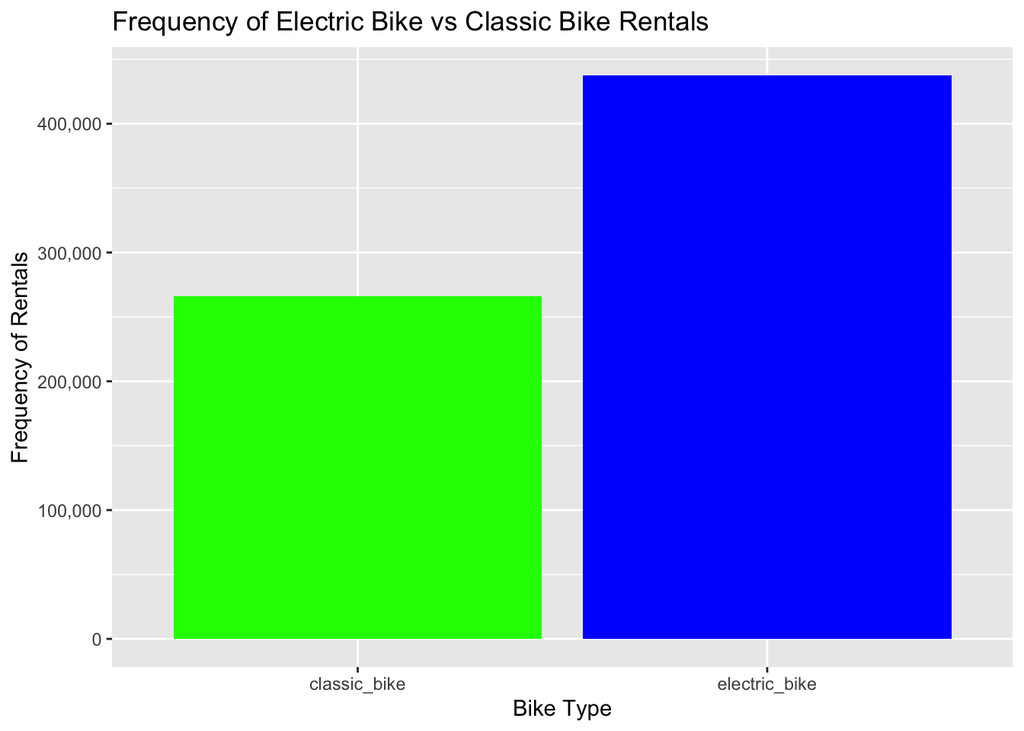

```r
bike_type_counts <- table(capital_bikeshare_clean$rideable_type)
bike_type_df <- as.data.frame(bike_type_counts)

ggplot(bike_type_df, aes(x = Var1, y = Freq, fill = Var1)) +
  geom_bar(stat = "identity") +
  labs(title = "Frequency of Electric Bike vs Classic Bike Rentals",
       x = "Bike Type",
       y = "Frequency of Rentals") +
  scale_fill_manual(values = c("electric_bike" = "blue", "classic_bike" = "green")) +
  scale_y_continuous(labels = scales::comma)+
  theme(legend.position = "none")
```

There is a higher frequency of electric bike rentals compared to classic bikes in the dataset indicates a preference for electric bikes.

## Distribution of duration rides on electric bike versus classic bike

*Histogram*

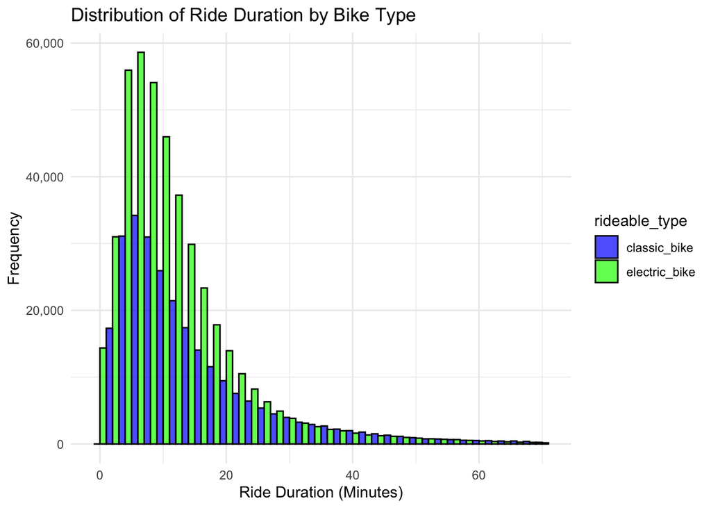

```r
ggplot(capital_bikeshare_clean, aes(x = ride_duration_mins, fill = rideable_type)) +
  geom_histogram(binwidth = 2, color = "black", alpha = 0.7, position = "dodge") +
  labs(
    title = "Distribution of Ride Duration by Bike Type",
    x = "Ride Duration (Minutes)",
    y = "Frequency"
  ) +
  scale_fill_manual(values = c("electric_bike" = "green", "classic_bike" = "blue")) +
  scale_y_continuous(labels = scales::comma) +
  theme_minimal()
```

*Box plot*

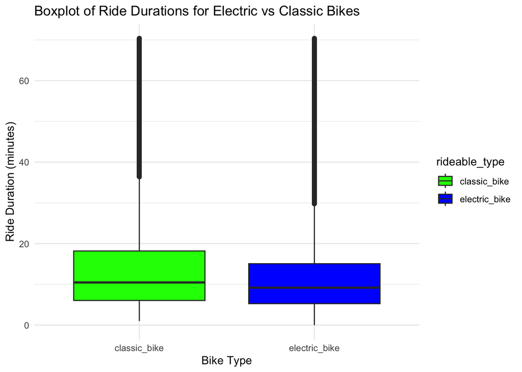

```r
ggplot(capital_bikeshare_clean, aes(x = rideable_type, y = ride_duration_mins, fill = rideable_type)) +
  geom_boxplot() +
  labs(title = "Boxplot of Ride Durations for Electric vs Classic Bikes",
       x = "Bike Type",
       y = "Ride Duration (minutes)") +
  scale_fill_manual(values = c("electric_bike" = "blue", "classic_bike" = "green")) +
  theme_minimal()
```

The distribution of ride duration by bike type is right-skewed, and the box plot highlights a significant number of extreme outliers.

## Distribution of distances ride by bike type.

*Histogram*

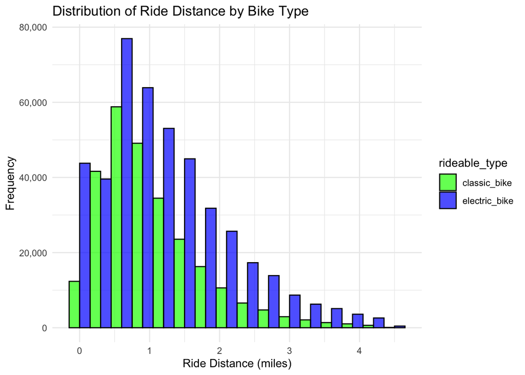

```r
ggplot(capital_bikeshare_clean, aes(x = distance_miles, fill = rideable_type)) +
  geom_histogram(binwidth = 0.3, color = "black", alpha = 0.7, position = "dodge") +
  labs(
    title = "Distribution of Ride Distance by Bike Type",
    x = "Ride Distance (miles)",
    y = "Frequency"
  ) +
  scale_fill_manual(values = c("electric_bike" = "blue", "classic_bike" = "green")) +
  scale_y_continuous(labels = scales::comma) +
  theme_minimal()
```

*Box-plot*

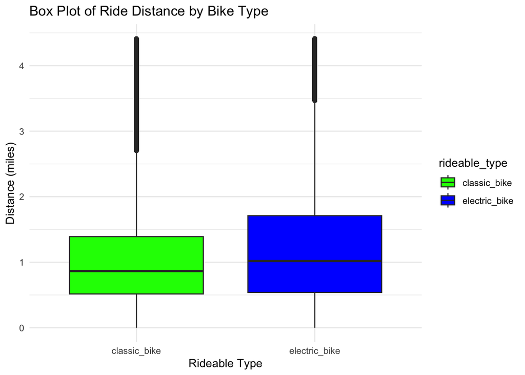

```r
ggplot(capital_bikeshare_clean, aes(x = rideable_type, y = distance_miles, fill = rideable_type)) +
  geom_boxplot() +
  labs(
    title = "Box Plot of Ride Distance by Bike Type",
    x = "Rideable Type",
    y = "Distance (miles)"
  ) +
  scale_fill_manual(values = c("electric_bike" = "blue", "classic_bike" = "green")) +
  theme_minimal()
```

The distribution of ride distance by bike type is slightly more right-skewed for classic bikes compared to electric bikes, with electric bikes exhibiting a wider distribution than classic bikes.

## Frequency of user types

```r
user_type_counts <- table(capital_bikeshare_clean$member_casual)
user_type_df <- as.data.frame(user_type_counts)
```

*Pie chart:*

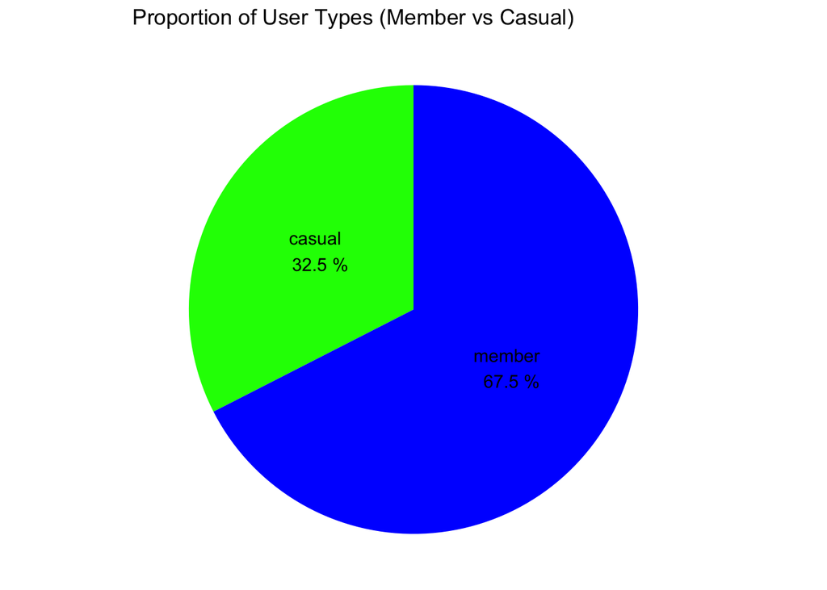

```r
user_type_df <- user_type_df %>%
  mutate(percentage = round(Freq / sum(Freq) * 100, 1))
ggplot(user_type_df, aes(x = "", y = Freq, fill = Var1)) +
  geom_bar(stat = "identity", width = 1) +
  coord_polar(theta = "y") +
  labs(title = "Proportion of User Types (Member vs Casual)") +
  scale_fill_manual(values = c("member" = "blue", "casual" = "green")) +
  theme_void() +
  geom_text(aes(label = paste(Var1, "\n", percentage, "%")), position = position_stack(vjust = 0.5)) +
  theme(legend.position = "none")
```

There is a higher percentage of member-type riders in October.

## User Types by Rideable Type

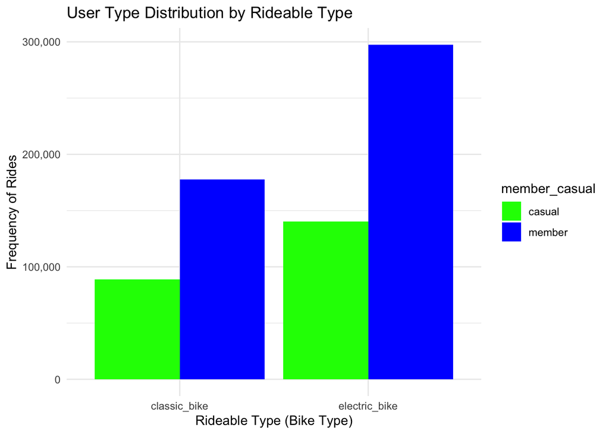

```r
user_bike_counts <- capital_bikeshare_clean %>%
  group_by(member_casual, rideable_type) %>%
  summarise(Freq = n())

ggplot(user_bike_counts, aes(x = rideable_type, y = Freq, fill = member_casual)) +
  geom_bar(stat = "identity", position = "dodge") +
  labs(title = "User Type Distribution by Rideable Type",
       x = "Rideable Type (Bike Type)",
       y = "Frequency of Rides") +
  scale_fill_manual(values = c("member" = "blue", "casual" = "green")) +
  theme_minimal() +
  scale_y_continuous(labels = scales::comma)
```

Electric bikes have a higher proportion of member-type riders compared to casual-type riders.

## Ride characteristics on weekdays vs weekends

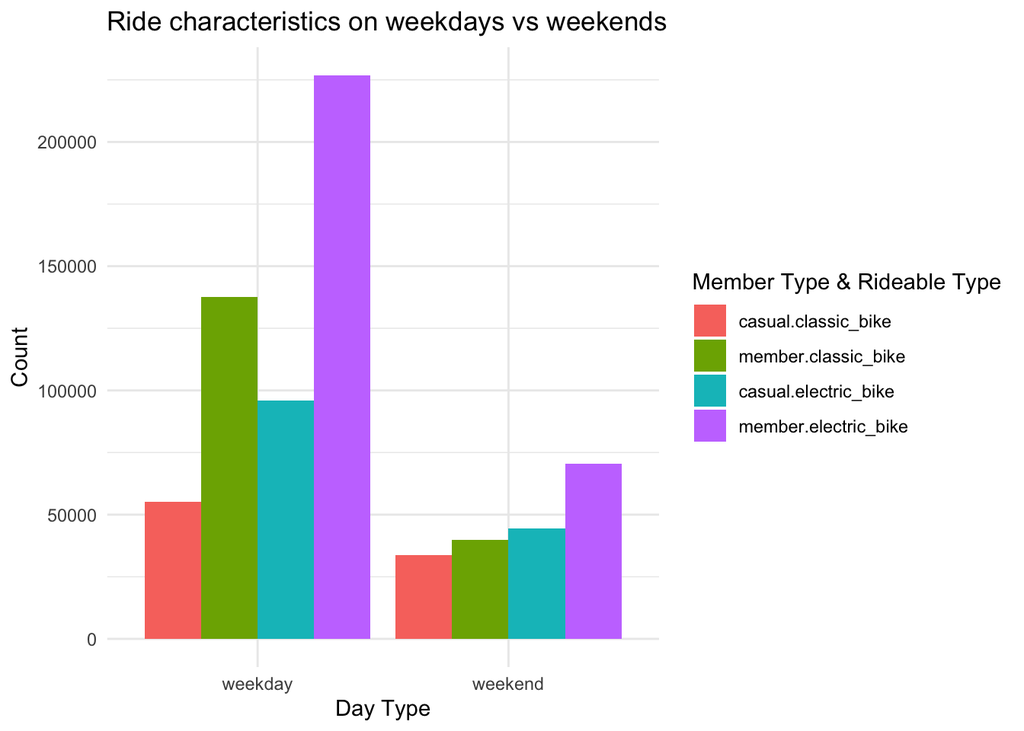

```r
ggplot(capital_bikeshare_clean, aes(x = day_type, fill = interaction(member_casual, rideable_type))) +
  geom_bar(position = "dodge") +
  labs(title = "Ride characteristics on weekdays vs weekends",
       x = "Day Type",
       y = "Count",
       fill = "Member Type & Rideable Type") +
  theme_minimal()
```

- Overall, there are fewer rides on weekends, with a significant decrease in rides by member-type users during the weekend.

# Predict the rider’s class based on trip characteristics

Our goal was to use trip characteristics to predict whether users are members or casual. This is a binary classification problem, so we utilized models suited to this type of problem: decision tree and logistic regression.

# Decision Tree

```r
# K-fold cross-validation
set.seed(123)
fold <- floor(runif(nrow(capital_bikeshare_clean), 1, 6))
capital_bikeshare_clean$fold <- fold

#vector to store results
accuracy_results <- c()

# Loop through each fold
for (i in 1:5) {
  # Create the test and training sets
  test.set <- capital_bikeshare_clean[capital_bikeshare_clean$fold == i,]
  train.set <- capital_bikeshare_clean[capital_bikeshare_clean$fold != i,]

  # Train the decision tree model
  Member_casual_tree <- rpart(member_casual ~ rideable_type + distance_miles + ride_duration_mins + start_time_period + day_type,
                              data = train.set,
                              method = "class")

  # Visualize the tree
  #rpart.plot(Member_casual_tree, type = 3, extra = 1, main = "Classification Tree for Member vs Casual Prediction")

  # summary of the tree
  printcp(Member_casual_tree)

  # predictions on the test set
  pred_prob <- predict(Member_casual_tree, test.set, type = "prob")

  # probabilities to predicted classes (1 for 'Member', 2 for 'Casual')
  pred_class <- ifelse(pred_prob[, 2] > 0.5, "casual", "member")  # Assuming 2nd class (casual) is the positive class

  #  accuracy of the current fold
  accuracy <- sum(pred_class == test.set$member_casual) / nrow(test.set)
  accuracy_results[i] <- accuracy
}
```

```
##
## Classification tree:
## rpart(formula = member_casual ~ rideable_type + distance_miles +
##     ride_duration_mins + start_time_period + day_type, data = train.set,
##     method = "class")
##
## Variables actually used in tree construction:
## [1] ride_duration_mins rideable_type
##
## Root node error: 2e+05/562631 = 0.3
##
## n= 562631
##
##     CP nsplit rel error xerror  xstd
## 1 0.02      0         1      1 0.002
## 2 0.01      2         1      1 0.002
##
## Classification tree:
## rpart(formula = member_casual ~ rideable_type + distance_miles +
##     ride_duration_mins + start_time_period + day_type, data = train.set,
##     method = "class")
##
## Variables actually used in tree construction:
## [1] ride_duration_mins rideable_type
##
## Root node error: 2e+05/563186 = 0.3
##
## n= 563186
##
##     CP nsplit rel error xerror  xstd
## 1 0.02      0         1      1 0.002
## 2 0.01      2         1      1 0.002
##
## Classification tree:
## rpart(formula = member_casual ~ rideable_type + distance_miles +
##     ride_duration_mins + start_time_period + day_type, data = train.set,
##     method = "class")
##
## Variables actually used in tree construction:
## [1] ride_duration_mins rideable_type
```

[output cut: 25 more lines]

```
## Classification tree:
## rpart(formula = member_casual ~ rideable_type + distance_miles +
##     ride_duration_mins + start_time_period + day_type, data = train.set,
##     method = "class")
##
## Variables actually used in tree construction:
## [1] ride_duration_mins rideable_type
##
## Root node error: 2e+05/563228 = 0.3
##
## n= 563228
##
##     CP nsplit rel error xerror  xstd
## 1 0.02      0         1      1 0.002
## 2 0.01      2         1      1 0.002
```

```r
# average accuracy across all folds
mean_accuracy <- mean(accuracy_results)
print(paste("Average accuracy across all folds: ", round(mean_accuracy, 4)))
```

```
## [1] "Average accuracy across all folds:  0.3113"
```

This analysis focuses on building a decision tree model to explore how features like rideable type, distance, ride duration, time of day, and day type influence the classification of bike riders as either “Member” or “Casual.” The methodology below outlines the steps for training, evaluating, and visualizing the model using K-fold cross-validation.

We assign each observation a fold number ranging from 1 to 5. This division allows each fold to act as a test set in turn while the rest of the data is used for training.

*Decision Tree Model Training* We use the `rpart` package in R to build a decision tree classifier. The target variable, member_casual, is predicted based on features - `rideable_type`, `distance_miles`, `ride_duration_mins`, `start_time_period`, `day_type`.

For each fold, the decision tree model is trained on the training dataset using the rpart function, with the method specified as “class” since it is a classification problem. The model is then summarized to obtain key information about the tree’s structure.

The accuracy for each fold is calculated by comparing the predicted class labels to the true labels in the test set. These accuracies are stored in the `accuracy_results` vector.

*Accuracy Calculation* After completing all five folds, the average accuracy across all folds is calculated. This average provides a more robust evaluation of the model’s performance, as it considers the variation across different subsets of the data.

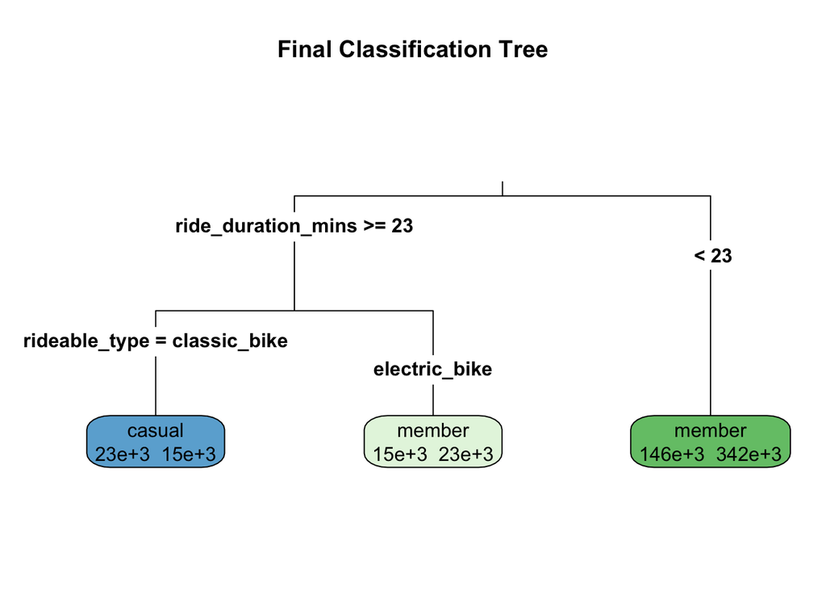

```r
# final tree visualization
rpart.plot(Member_casual_tree, type = 3, extra = 1, main = "Final Classification Tree")
```

#### Key insights: